# Crossroads Baseball Project.

# Welcome!

These are the results from our project. You can check out how we did everything here:

[Project](https://mathatgrace.github.io/CrossRoads-Baseball/)

## Overview

On this site you will find park factors, the top hitters in the conference, projections for upcoming games, and a searchable table containing stats for all hitters in the Crossroads League.

# Park Factor

Park Factor is a measurement of an individual ballpark’s potential impact on the game. This number will take into account factors such as altitude and dimensions of the field. In the graph below, the line segment in the middle represents a park value of 1, which is considered a “neutral” park.

A value greater than 1 indicates the park favors the hitter. Oftentimes this suggests more total hits and/or more total runs will be scored than an average game played at a neutral park. For example, in Major League Baseball, the home field for the Colorado Rockies, Coors Field, had a park factor of 1.33 in 2019. Coors Field is located in Denver, meaning the park sits one mile above sea level. At this altitude a baseball carries farther, resulting in more home runs. Thus, Coors Field is a hitter friendly park. Altitude is not the only cause of differences in park factors. Small parks, such as Fenway Park in Boston, also are considered hitter friendly. The fences at Fenway are closer to home plate than at most other parks. Thus, a baseball hit 340 feet to right field may be a home run in Boston, while being an out in Milwaukee. This is the significance of the park factor statistic.

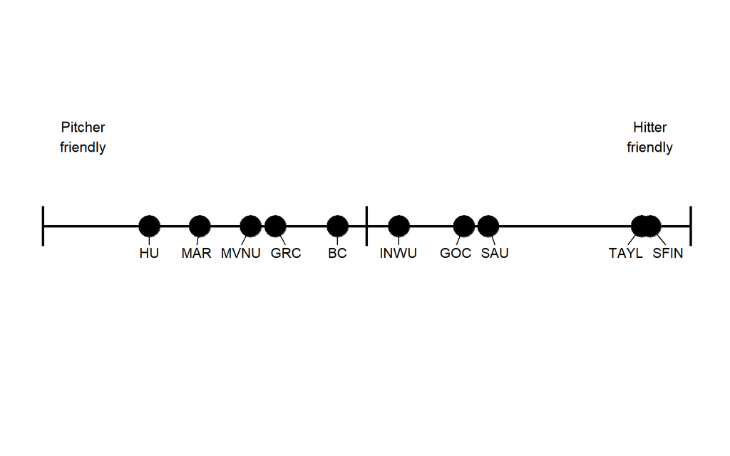

# Top Hitters in the Crossroads League

After compiling advanced batting statistics for each team, we chose to use weighted runs created plus (wRC+) in order to evaluate a hitter’s overall contribution to the team. This statistic takes park factor into account, as well as adjusting based on a player’s performance in comparison to the league average.

The following is a list of the top hitters in the Crossroads League in 2019 based on wRC+.

| Rank | Team | Player | wRC+ | PA |
| --- | --- | --- | --- | --- |
| 1 | MVNU | Myers, Ashton | 191.72 | 217 |
| 2 | INWU | Eder, Caleb | 179.54 | 218 |
| 3 | MVNU | Glover, Jake | 178.1 | 203 |
| 4 | GRC | Griffin, Chris | 172.83 | 164 |
| 5 | INWU | English, Ethan | 172.73 | 162 |
| 6 | HU | Hansen, Jacob | 167.9 | 55 |
| 7 | HU | Lichty, Daniel | 165.63 | 177 |
| 8 | GOC | Stroble ii, Clinton | 157.25 | 186 |
| 9 | SAU | Lengerich, Conner | 155.63 | 215 |
| 10 | MVNU | Miller, Kobe | 154.25 | 53 |

[output cut: 130 more lines]

# Top Pitchers in the Crossroads League

We chose to measure pitchers using Fielding Indepent Pitching (FIP). This metric attempts to isolate the performance of the pitcher, stripping away the influence of the defense as well as luck. Similar to the wRC+ stat for hitters, FIP also adjusts based on a league constant. The scale for FIP is similar to ERA; a lower FIP is better.

The following is a list of the top pitchers in the Crossroads League in 2019 based on FIP (minimum 25 IP).

| Rank | Team | Player | FIP | IP | K | ERA |
| --- | --- | --- | --- | --- | --- | --- |
| 1 | TAYL | Ubelhor, Mitch | 2.41 | 33.1 | 54 | 1.08 |
| 2 | MVNU | Goodpaster, Adam | 3.21 | 31 | 36 | 2.32 |
| 3 | GOC | Evans, Braedon | 3.35 | 36 | 40 | 2.75 |
| 4 | HU | Moore, DJ | 3.41 | 47.1 | 54 | 5.13 |
| 5 | MAR | Burleton, Matt | 3.43 | 105.1 | 87 | 1.37 |
| 6 | GRC | Haney, Houston | 3.49 | 54.1 | 48 | 3.64 |
| 7 | BC | Goodrich, Kory | 3.88 | 36.1 | 29 | 4.95 |
| 8 | INWU | Eder, Caleb | 3.93 | 50.2 | 60 | 4.09 |
| 9 | GOC | Malson, Colby | 3.96 | 49 | 56 | 2.94 |
| 10 | HU | Mccutcheon, Alex | 4.02 | 79 | 99 | 2.51 |

[output cut: 55 more lines]

# Upcoming Games

The next game is Indiana Wesleyan vs. Grace at Grace.

```
[1] 0.6771401
[1] 0.3228599
$GRC
[1] 0.8870968
```

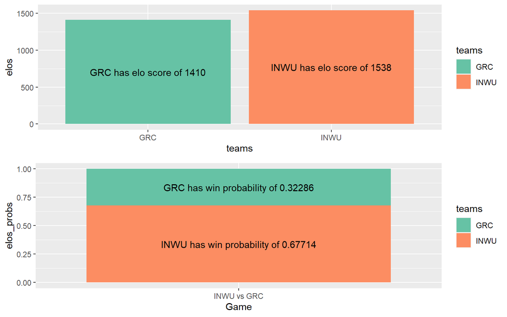

# Simulation

Due to the COVID-19 outbreak in 2020, we were unable to compare our predictions to the actual outcome of games. Instead, we have created a tournament simulation that uses the 2019 elo ratings along with the 2020 preseason coaches’ poll to simulate what the season might have been like. Since this simulation uses random numbers, each time you refresh or check the website, the results will be slightly different.

```
   Team Record
1    HU    8-1
2  MVNU    7-2
3  INWU    8-1
4  TAYL    4-5
5   MAR    2-7
6   SAU    2-7
7    BC    5-4
8   GOC    7-2
9   GRC    2-7
10 SFIN    0-9
```

```
      HU     INWU     MVNU       BC      GOC     TAYL      MAR      GRC
1647.580 1646.828 1574.803 1528.359 1515.822 1446.363 1410.072 1330.477
     SAU     SFIN
1289.192 1178.452
```